# Homework 4

3. Random Forest

```r
sqrt(ncol(Traindat))
```

```
## [1] 7.549834
```

```r
#We choose values around this value
Grid.Matrix= expand.grid(mtry=c(4,5,6,7,8,10))
control.param$allowParallel<-T
cl <- makeCluster(8)
registerDoSNOW(cl)
set.seed(123)
fit.rf <- caret::train(x = Traindat ,
                       y = TrainResponse,
                       method = "rf",
                       trControl = control.param,
                       tuneGrid = Grid.Matrix,
                       metric="Accuracy",
                       ntree=500,
                       nodesize=5)
stopCluster(cl)

print(fit.rf)
```

```
## Random Forest
##
## 3220 samples
##   57 predictor
##    2 classes: 'non_spam', 'spam'
##
## No pre-processing
## Resampling: Cross-Validated (10 fold)
## Summary of sample sizes: 2898, 2898, 2897, 2898, 2898, 2899, ...
## Resampling results across tuning parameters:
##
##   mtry  Accuracy   Kappa
##    4    0.9496786  0.8935256
##    5    0.9493709  0.8928774
##    6    0.9493700  0.8929308
##    7    0.9456481  0.8850695
##    8    0.9490633  0.8922226
##   10    0.9487566  0.8917535
##
## Accuracy was used to select the optimal model using the largest value.
## The final value used for the model was mtry = 4.
```

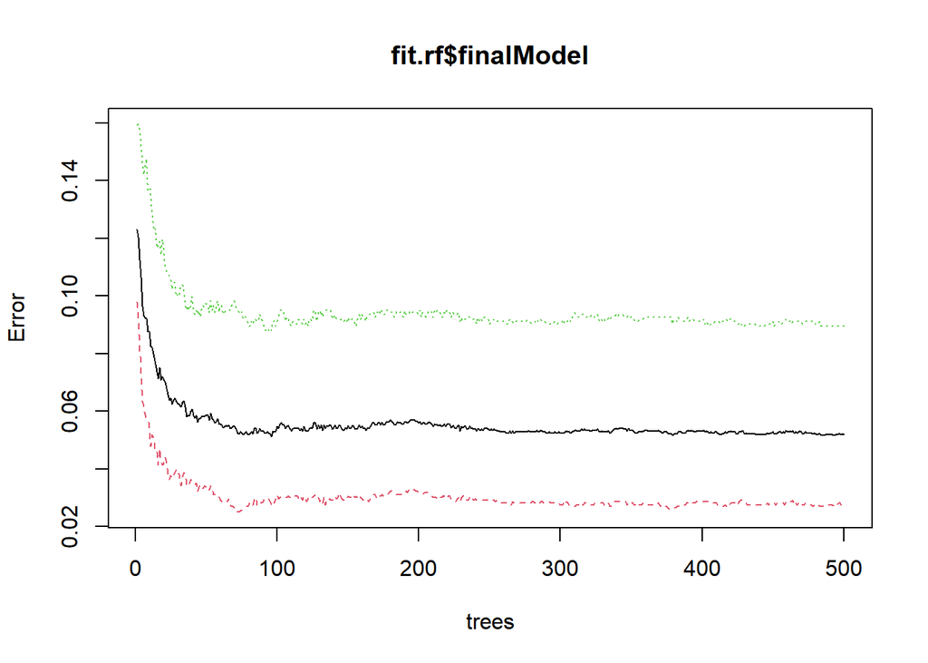

```r
plot(fit.rf$finalModel)
```

It looks like we are not overfitting

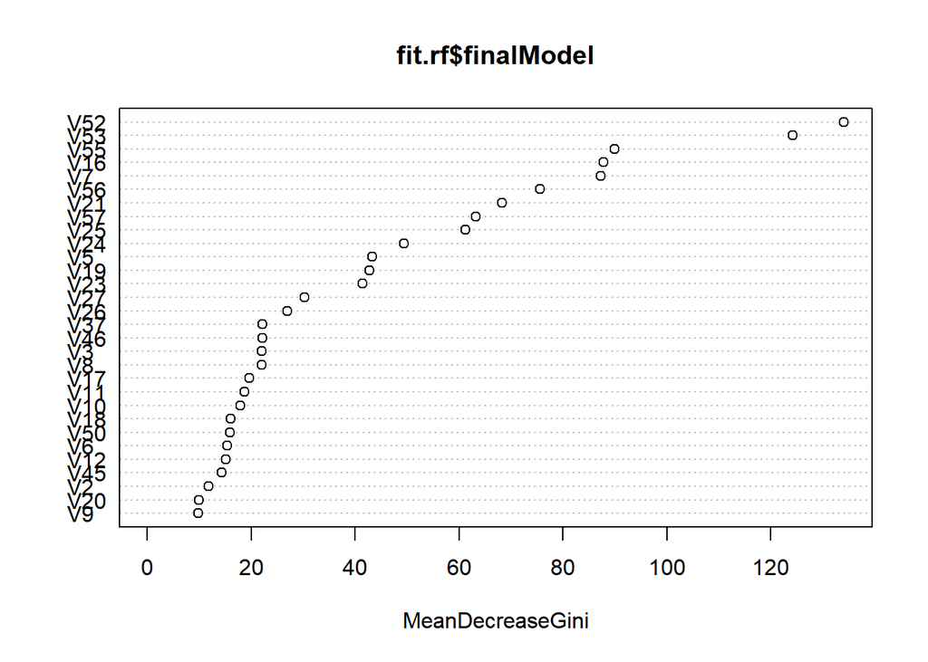

```r
varImpPlot(fit.rf$finalModel)
```

```r
imp<-data.frame(fit.rf$finalModel$importance,var = rownames(fit.rf$finalModel$importance))
imp %>% arrange(desc(MeanDecreaseGini)) %>%
  mutate(csum_gini=cumsum(MeanDecreaseGini)) %>%
  print()
```

```
##    MeanDecreaseGini var csum_gini
## 1       134.1448970 V52  134.1449
## 2       124.1867634 V53  258.3317
## 3        89.9071845 V55  348.2388
## 4        87.8500361 V16  436.0889
## 5        87.2936106  V7  523.3825
## 6        75.6129767 V56  598.9955
## 7        68.2088338 V21  667.2043
## 8        63.2772963 V57  730.4816
## 9        61.1963583 V25  791.6780
## 10       49.3458165 V24  841.0238
## 11       43.2681161  V5  884.2919
## 12       42.7134456 V19  927.0053
## 13       41.3681556 V23  968.3735
## 14       30.2659027 V27  998.6394
```

[output cut: 43 more lines]

```r
#First 10 variables V52 to V24 covers more than 50% of total gini decrease
```

```r
rf.preds.prob<-predict(fit.rf,test_spam,type = "prob")[,"spam"]
#If we do not want false positives we can increase threshold
#If we do not want false negatives we can decrease threshold
for(thr in seq(0.2,0.8,by=0.2)){
  rf.preds<-ifelse(rf.preds.prob>thr,"spam","non_spam")
  conf.mat<-confusionMatrix(table(rf.preds,test_spam$Y))
  print(thr)
  print(conf.mat)
}
```

```
## [1] 0.2
## Confusion Matrix and Statistics
##
##
## rf.preds   non_spam spam
##   non_spam      715   12
##   spam          115  539
##
##                Accuracy : 0.908
##                  95% CI : (0.8916, 0.9228)
##     No Information Rate : 0.601
##     P-Value [Acc > NIR] : < 2.2e-16
##
##                   Kappa : 0.8141
##
##  Mcnemar's Test P-Value : < 2.2e-16
##
##             Sensitivity : 0.8614
##             Specificity : 0.9782
##          Pos Pred Value : 0.9835
##          Neg Pred Value : 0.8242
##              Prevalence : 0.6010
##          Detection Rate : 0.5177
##    Detection Prevalence : 0.5264
##       Balanced Accuracy : 0.9198
##
##        'Positive' Class : non_spam
##
## [1] 0.4
## Confusion Matrix and Statistics
##
##
## rf.preds   non_spam spam
##   non_spam      793   31
##   spam           37  520
##
##                Accuracy : 0.9508
##                  95% CI : (0.938, 0.9616)
##     No Information Rate : 0.601
##     P-Value [Acc > NIR] : <2e-16
```

[output cut: 57 more lines]

```
##                   Kappa : 0.7603
##
##  Mcnemar's Test P-Value : < 2.2e-16
##
##             Sensitivity : 0.9928
##             Specificity : 0.7350
##          Pos Pred Value : 0.8495
##          Neg Pred Value : 0.9854
##              Prevalence : 0.6010
##          Detection Rate : 0.5967
##    Detection Prevalence : 0.7024
##       Balanced Accuracy : 0.8639
##
##        'Positive' Class : non_spam
##
```

```r
rf.preds<-ifelse(rf.preds.prob>0.5,"spam","non_spam")
conf.mat<-confusionMatrix(table(rf.preds,test_spam$Y))
print(conf.mat)
```

```
## Confusion Matrix and Statistics
##
##
## rf.preds   non_spam spam
##   non_spam      805   42
##   spam           25  509
##
##                Accuracy : 0.9515
##                  95% CI : (0.9388, 0.9622)
##     No Information Rate : 0.601
##     P-Value [Acc > NIR] : < 2e-16
##
##                   Kappa : 0.8983
##
##  Mcnemar's Test P-Value : 0.05062
##
##             Sensitivity : 0.9699
##             Specificity : 0.9238
##          Pos Pred Value : 0.9504
##          Neg Pred Value : 0.9532
##              Prevalence : 0.6010
##          Detection Rate : 0.5829
##    Detection Prevalence : 0.6133
##       Balanced Accuracy : 0.9468
##
##        'Positive' Class : non_spam
##
```

```r
# We correctly classified 95% of e-mails
# We passed 42 spam e-mails and filtered 25 non spam e-mails

rf.perf<-conf.mat$overall["Accuracy"]
print(rf.perf)
```

```
##  Accuracy
## 0.9514844
```

Accuracy has improved to 95% which is great.

4. Stochastic Gradient Boosting

For this question we increase n.trees because with n.trees of 200 best selected parameters are n.trees=200, depth=12, shrinkage=0.1. So, I solve the issue by increasing n.trees

```r
Grid.Matrix= expand.grid(n.trees=seq(20,400,length.out = 6),
                         interaction.depth=c(3,5,7,9,12),
                         shrinkage=c(0.005,0.01,0.03,0.05,0.1),
                         n.minobsinnode=c(10))
cl <- makeCluster(8)
registerDoSNOW(cl)
set.seed(123)
fit.gbm <- caret::train(x = Traindat ,
                        y = TrainResponse,
                        method = "gbm",
                        trControl = control.param,
                        tuneGrid = Grid.Matrix,
                        metric="Accuracy")
stopCluster(cl)
print(fit.gbm)
```

```
## Stochastic Gradient Boosting
##
## 3220 samples
##   57 predictor
##    2 classes: 'non_spam', 'spam'
##
## No pre-processing
## Resampling: Cross-Validated (10 fold)
## Summary of sample sizes: 2898, 2898, 2897, 2898, 2898, 2899, ...
## Resampling results across tuning parameters:
##
##   shrinkage  interaction.depth  n.trees  Accuracy   Kappa
##   0.005       3                  20      0.6080749  0.0000000
##   0.005       3                  96      0.8608632  0.6919659
##   0.005       3                 172      0.8990573  0.7822267
##   0.005       3                 248      0.9077646  0.8022241
##   0.005       3                 324      0.9142825  0.8167699
##   0.005       3                 400      0.9192515  0.8275583
##   0.005       5                  20      0.6080749  0.0000000
##   0.005       5                  96      0.8934701  0.7687170
##   0.005       5                 172      0.9093145  0.8061290
##   0.005       5                 248      0.9145959  0.8179148
##   0.005       5                 324      0.9186323  0.8267255
##   0.005       5                 400      0.9204947  0.8307867
##   0.005       7                  20      0.6080749  0.0000000
##   0.005       7                  96      0.9049628  0.7951816
##   0.005       7                 172      0.9158353  0.8203573
##   0.005       7                 248      0.9161507  0.8213546
##   0.005       7                 324      0.9195668  0.8290845
##   0.005       7                 400      0.9245339  0.8397487
##   0.005       9                  20      0.6080749  0.0000000
##   0.005       9                  96      0.9043436  0.7938393
##   0.005       9                 172      0.9155276  0.8197277
##   0.005       9                 248      0.9195678  0.8289791
##   0.005       9                 324      0.9260896  0.8431725
##   0.005       9                 400      0.9298124  0.8511051
##   0.005      12                  20      0.6080749  0.0000000
##   0.005      12                  96      0.9108663  0.8082296
##   0.005      12                 172      0.9198764  0.8293824
##   0.005      12                 248      0.9242262  0.8391385
```

[output cut: 112 more lines]

```
##   0.100       9                 172      0.9481384  0.8908744
##   0.100       9                 248      0.9515468  0.8981061
##   0.100       9                 324      0.9531035  0.9013994
##   0.100       9                 400      0.9518622  0.8987504
##   0.100      12                  20      0.9304393  0.8526716
##   0.100      12                  96      0.9521737  0.8992073
##   0.100      12                 172      0.9558966  0.9071167
##   0.100      12                 248      0.9552716  0.9059072
##   0.100      12                 324      0.9543399  0.9040272
##   0.100      12                 400      0.9540303  0.9033326
##
## Tuning parameter 'n.minobsinnode' was held constant at a value of 10
## Accuracy was used to select the optimal model using the largest value.
## The final values used for the model were n.trees = 172, interaction.depth =
##  12, shrinkage = 0.1 and n.minobsinnode = 10.
```

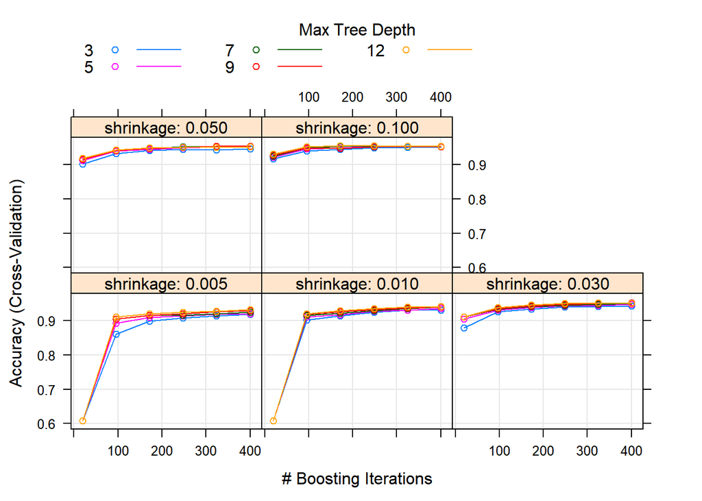

```r
plot(fit.gbm)
```

```r
varImp(fit.gbm)
```

```
## gbm variable importance
##
##   only 20 most important variables shown (out of 57)
##
##     Overall
## V53 100.000
## V52  76.579
## V7   43.602
## V25  22.911
## V16  21.547
## V55  21.317
## V57  15.672
## V56  13.954
## V5    9.313
## V21   8.569
## V27   7.443
## V46   6.431
## V24   6.282
## V19   5.670
## V23   4.554
## V45   3.749
## V11   3.730
## V37   3.431
## V50   2.944
## V12   2.846
```

```r
#V52,V7, V53 are the most important features according to gbm model
```

```r
gbm.preds.rpbo=predict(fit.gbm,test_spam,type = "prob")[,"spam"]
for(thr in seq(0.2,0.8,by=0.2)){
  gbm.preds<-ifelse(gbm.preds.rpbo>thr,"spam","non_spam")
  conf.mat<-confusionMatrix(table(gbm.preds,test_spam$Y))
  print(thr)
  print(conf.mat)
}
```

```
## [1] 0.2
## Confusion Matrix and Statistics
##
##
## gbm.preds  non_spam spam
##   non_spam      768   17
##   spam           62  534
##
##                Accuracy : 0.9428
##                  95% CI : (0.9292, 0.9545)
##     No Information Rate : 0.601
##     P-Value [Acc > NIR] : < 2.2e-16
##
##                   Kappa : 0.8823
##
##  Mcnemar's Test P-Value : 7.407e-07
##
##             Sensitivity : 0.9253
##             Specificity : 0.9691
##          Pos Pred Value : 0.9783
##          Neg Pred Value : 0.8960
##              Prevalence : 0.6010
##          Detection Rate : 0.5561
##    Detection Prevalence : 0.5684
##       Balanced Accuracy : 0.9472
##
##        'Positive' Class : non_spam
##
## [1] 0.4
## Confusion Matrix and Statistics
##
##
## gbm.preds  non_spam spam
##   non_spam      795   28
##   spam           35  523
##
##                Accuracy : 0.9544
##                  95% CI : (0.942, 0.9648)
##     No Information Rate : 0.601
##     P-Value [Acc > NIR] : <2e-16
```

[output cut: 57 more lines]

```
##                   Kappa : 0.8868
##
##  Mcnemar's Test P-Value : 1.878e-06
##
##             Sensitivity : 0.9807
##             Specificity : 0.8947
##          Pos Pred Value : 0.9335
##          Neg Pred Value : 0.9686
##              Prevalence : 0.6010
##          Detection Rate : 0.5894
##    Detection Prevalence : 0.6314
##       Balanced Accuracy : 0.9377
##
##        'Positive' Class : non_spam
##
```

```r
gbm.preds<-ifelse(gbm.preds.rpbo>0.5,"spam","non_spam")
conf.mat<-confusionMatrix(table(gbm.preds,test_spam$Y))
print(conf.mat)
```

```
## Confusion Matrix and Statistics
##
##
## gbm.preds  non_spam spam
##   non_spam      799   32
##   spam           31  519
##
##                Accuracy : 0.9544
##                  95% CI : (0.942, 0.9648)
##     No Information Rate : 0.601
##     P-Value [Acc > NIR] : <2e-16
##
##                   Kappa : 0.9049
##
##  Mcnemar's Test P-Value : 1
##
##             Sensitivity : 0.9627
##             Specificity : 0.9419
##          Pos Pred Value : 0.9615
##          Neg Pred Value : 0.9436
##              Prevalence : 0.6010
##          Detection Rate : 0.5786
##    Detection Prevalence : 0.6017
##       Balanced Accuracy : 0.9523
##
##        'Positive' Class : non_spam
##
```

```r
# We correctly classified 95% of e-mails
# We passed 32 spam e-mails and filtered 31 non spam e-mails

gbm.perf<-conf.mat$overall["Accuracy"]
print(gbm.perf)
```

```
##  Accuracy
## 0.9543809
```

```r
spam_perfs<-cbind(c(glmnet.perf,rpart.perf,rf.perf,gbm.perf),
                  c(max(fit.glmnet$results$Accuracy),fit.rpart$y["acc.test.mean"],max(fit.rf$results$Accuracy),max(fit.gbm$results$Accuracy)))


colnames(spam_perfs)<-c("Test","CV")
rownames(spam_perfs)<-c("glmnet","rpart","rf","gbm")
spam_perfs
```

```
##             Test        CV
## glmnet 0.9283128 0.9285673
## rpart  0.9312093 0.9124224
## rf     0.9514844 0.9496786
## gbm    0.9543809 0.9558966
```

GBM performed best for this question however it is very close to random forest. rpart performed better than glmnet. So, maybe rpart is generally better than glmnet for classification. We will see if this inference is correct in next questions.

3. THIRD PROBLEM: IMBALANCED CLASSIFICATION

The data is taken from here: https://www.kaggle.com/mlg-ulb/creditcardfraud

Content: The datasets contains transactions made by credit cards in September 2013 by european cardholders. This dataset presents transactions that occurred in two days, where we have 492 frauds out of 284,807 transactions. The dataset is highly unbalanced, the positive class (frauds) account for 0.172% of all transactions.

It contains only numerical input variables which are the result of a PCA transformation. Unfortunately, due to confidentiality issues, we cannot provide the original features and more background information about the data. Features V1, V2, … V28 are the principal components obtained with PCA, the only features which have not been transformed with PCA are ‘Time’ and ‘Amount’. Feature ‘Time’ contains the seconds elapsed between each transaction and the first transaction in the dataset. The feature ‘Amount’ is the transaction Amount, this feature can be used for example-dependant cost-senstive learning. Feature ‘Class’ is the response variable and it takes value 1 in case of fraud and 0 otherwise.

Given the class imbalance ratio, we recommend measuring the accuracy using the Area Under the Precision-Recall Curve (AUPRC). Confusion matrix accuracy is not meaningful for unbalanced classification.

Acknowledgements The dataset has been collected and analysed during a research collaboration of Worldline and the Machine Learning Group (http://mlg.ulb.ac.be) of ULB (Université Libre de Bruxelles) on big data mining and fraud detection.

```r
credit_raw<-tibble(read.csv("creditcard.csv",sep = ","))

dim(credit_raw)
```

```
## [1] 284807     31
```

```r
any(is.na(credit_raw))# no missing values
```

```
## [1] FALSE
```

```r
summary(credit_raw)
```

```
##       Time              V1                  V2                  V3
##  Min.   :     0   Min.   :-56.40751   Min.   :-72.71573   Min.   :-48.3256
##  1st Qu.: 54202   1st Qu.: -0.92037   1st Qu.: -0.59855   1st Qu.: -0.8904
##  Median : 84692   Median :  0.01811   Median :  0.06549   Median :  0.1799
##  Mean   : 94814   Mean   :  0.00000   Mean   :  0.00000   Mean   :  0.0000
##  3rd Qu.:139321   3rd Qu.:  1.31564   3rd Qu.:  0.80372   3rd Qu.:  1.0272
##  Max.   :172792   Max.   :  2.45493   Max.   : 22.05773   Max.   :  9.3826
##        V4                 V5                   V6                 V7
##  Min.   :-5.68317   Min.   :-113.74331   Min.   :-26.1605   Min.   :-43.5572
##  1st Qu.:-0.84864   1st Qu.:  -0.69160   1st Qu.: -0.7683   1st Qu.: -0.5541
##  Median :-0.01985   Median :  -0.05434   Median : -0.2742   Median :  0.0401
##  Mean   : 0.00000   Mean   :   0.00000   Mean   :  0.0000   Mean   :  0.0000
##  3rd Qu.: 0.74334   3rd Qu.:   0.61193   3rd Qu.:  0.3986   3rd Qu.:  0.5704
##  Max.   :16.87534   Max.   :  34.80167   Max.   : 73.3016   Max.   :120.5895
##        V8                  V9                 V10                 V11
##  Min.   :-73.21672   Min.   :-13.43407   Min.   :-24.58826   Min.   :-4.79747
##  1st Qu.: -0.20863   1st Qu.: -0.64310   1st Qu.: -0.53543   1st Qu.:-0.76249
##  Median :  0.02236   Median : -0.05143   Median : -0.09292   Median :-0.03276
##  Mean   :  0.00000   Mean   :  0.00000   Mean   :  0.00000   Mean   : 0.00000
##  3rd Qu.:  0.32735   3rd Qu.:  0.59714   3rd Qu.:  0.45392   3rd Qu.: 0.73959
##  Max.   : 20.00721   Max.   : 15.59500   Max.   : 23.74514   Max.   :12.01891
##       V12                V13                V14                V15
##  Min.   :-18.6837   Min.   :-5.79188   Min.   :-19.2143   Min.   :-4.49894
##  1st Qu.: -0.4056   1st Qu.:-0.64854   1st Qu.: -0.4256   1st Qu.:-0.58288
##  Median :  0.1400   Median :-0.01357   Median :  0.0506   Median : 0.04807
##  Mean   :  0.0000   Mean   : 0.00000   Mean   :  0.0000   Mean   : 0.00000
##  3rd Qu.:  0.6182   3rd Qu.: 0.66251   3rd Qu.:  0.4931   3rd Qu.: 0.64882
##  Max.   :  7.8484   Max.   : 7.12688   Max.   : 10.5268   Max.   : 8.87774
##       V16                 V17                 V18
##  Min.   :-14.12985   Min.   :-25.16280   Min.   :-9.498746
##  1st Qu.: -0.46804   1st Qu.: -0.48375   1st Qu.:-0.498850
##  Median :  0.06641   Median : -0.06568   Median :-0.003636
##  Mean   :  0.00000   Mean   :  0.00000   Mean   : 0.000000
##  3rd Qu.:  0.52330   3rd Qu.:  0.39968   3rd Qu.: 0.500807
##  Max.   : 17.31511   Max.   :  9.25353   Max.   : 5.041069
##       V19                 V20                 V21
##  Min.   :-7.213527   Min.   :-54.49772   Min.   :-34.83038
##  1st Qu.:-0.456299   1st Qu.: -0.21172   1st Qu.: -0.22839
##  Median : 0.003735   Median : -0.06248   Median : -0.02945
##  Mean   : 0.000000   Mean   :  0.00000   Mean   :  0.00000
```

[output cut: 8 more lines]

```
##  Max.   : 10.503090   Max.   : 22.52841   Max.   : 4.58455
##       V25                 V26                V27
##  Min.   :-10.29540   Min.   :-2.60455   Min.   :-22.565679
##  1st Qu.: -0.31715   1st Qu.:-0.32698   1st Qu.: -0.070840
##  Median :  0.01659   Median :-0.05214   Median :  0.001342
##  Mean   :  0.00000   Mean   : 0.00000   Mean   :  0.000000
##  3rd Qu.:  0.35072   3rd Qu.: 0.24095   3rd Qu.:  0.091045
##  Max.   :  7.51959   Max.   : 3.51735   Max.   : 31.612198
##       V28                Amount             Class
##  Min.   :-15.43008   Min.   :    0.00   Min.   :0.000000
##  1st Qu.: -0.05296   1st Qu.:    5.60   1st Qu.:0.000000
##  Median :  0.01124   Median :   22.00   Median :0.000000
##  Mean   :  0.00000   Mean   :   88.35   Mean   :0.001728
##  3rd Qu.:  0.07828   3rd Qu.:   77.17   3rd Qu.:0.000000
##  Max.   : 33.84781   Max.   :25691.16   Max.   :1.000000
```

```r
str(credit_raw)
```

```
## tibble [284,807 x 31] (S3: tbl_df/tbl/data.frame)
##  $ Time  : num [1:284807] 0 0 1 1 2 2 4 7 7 9 ...
##  $ V1    : num [1:284807] -1.36 1.192 -1.358 -0.966 -1.158 ...
##  $ V2    : num [1:284807] -0.0728 0.2662 -1.3402 -0.1852 0.8777 ...
##  $ V3    : num [1:284807] 2.536 0.166 1.773 1.793 1.549 ...
##  $ V4    : num [1:284807] 1.378 0.448 0.38 -0.863 0.403 ...
##  $ V5    : num [1:284807] -0.3383 0.06 -0.5032 -0.0103 -0.4072 ...
##  $ V6    : num [1:284807] 0.4624 -0.0824 1.8005 1.2472 0.0959 ...
##  $ V7    : num [1:284807] 0.2396 -0.0788 0.7915 0.2376 0.5929 ...
##  $ V8    : num [1:284807] 0.0987 0.0851 0.2477 0.3774 -0.2705 ...
##  $ V9    : num [1:284807] 0.364 -0.255 -1.515 -1.387 0.818 ...
##  $ V10   : num [1:284807] 0.0908 -0.167 0.2076 -0.055 0.7531 ...
##  $ V11   : num [1:284807] -0.552 1.613 0.625 -0.226 -0.823 ...
##  $ V12   : num [1:284807] -0.6178 1.0652 0.0661 0.1782 0.5382 ...
##  $ V13   : num [1:284807] -0.991 0.489 0.717 0.508 1.346 ...
```

[output cut: 17 more lines]

```r
credit<-credit_raw %>%
  rename(Y=Class) %>%
  mutate(Y=ifelse(Y==1,"fraud",
                  ifelse(Y==0,"non_fraud",NA)))
table(credit$Y)
```

```
##
##     fraud non_fraud
##       492    284315
```

We need to reduce the data since it is too large and takes so much time. So I will choose 5000 instance from class non_fraud and 100 from class fraud

Performance metric is balanced accuracy since problem is unbalanced classification and traditional accuracy is not good idea for these kind of problems.

```r
set.seed(123)
classnonfrauds<-credit %>% filter(Y=="non_fraud") %>% filter(row_number() %in% sample(1:nrow(.),5000,replace=F))
classfrauds<-credit %>% filter(Y=="fraud") %>% filter(row_number() %in% sample(1:nrow(.),100,replace=F))
credit<-bind_rows(classfrauds,classnonfrauds)
table(credit$Y)
```

```
##
##     fraud non_fraud
##       100      5000
```

```r
# 30% of data is selected for test
set.seed(123)
TrainIndex <- sample(1:nrow(credit),size = trunc(nrow(credit)*0.7),replace = F)

train_credit<- credit[TrainIndex,] %>% as.data.frame()
test_credit<- credit[-TrainIndex,] %>% as.data.frame()

Traindat<-train_credit %>% select(-Y)
TrainResponse<-train_credit$Y

control.param<-trainControl(method = "cv",
                            number = 10,
                            allowParallel = F,
                            returnResamp = "all",
                            savePredictions = "all",
                            classProbs = T,
                            summaryFunction = multiClassSummary)
```

1. Glmnet Method

```r
Grid.Matrix= expand.grid(alpha=1,
                         lambda=c(0.0001,0.001,0.005,0.01,0.05,0.1))


set.seed(123)
fit.glmnet <- caret::train(x = Traindat ,
                           y = TrainResponse,
                           method = "glmnet",
                           trControl = control.param,
                           tuneGrid = Grid.Matrix,
                           metric="Balanced_Accuracy")
print(fit.glmnet)
```

```
## glmnet
##
## 3570 samples
##   30 predictor
##    2 classes: 'fraud', 'non_fraud'
##
## No pre-processing
## Resampling: Cross-Validated (10 fold)
## Summary of sample sizes: 3213, 3213, 3212, 3213, 3213, 3213, ...
## Resampling results across tuning parameters:
##
##   lambda  logLoss     AUC        prAUC      Accuracy   Kappa      F1
##   1e-04   0.03140873  0.9599248  0.7992750  0.9949595  0.8508705  0.8532853
##   1e-03   0.02053987  0.9800427  0.8678891  0.9960808  0.8715787  0.8734033
##   5e-03   0.02433448  0.9741327  0.8644364  0.9955206  0.8530208  0.8551049
##   1e-02   0.02908972  0.9567595  0.8572393  0.9927186  0.7461238  0.7492618
##   5e-02   0.05051754  0.9568025  0.8531731  0.9859952  0.4027605  0.4517957
##   1e-01   0.09541230  0.5000000  0.0000000  0.9806730  0.0000000        NaN
##   Sensitivity  Specificity  Pos_Pred_Value  Neg_Pred_Value  Precision
##   0.8142857    0.9985714    0.9408333       0.9963140       0.9408333
##   0.8000000    1.0000000    1.0000000       0.9960348       1.0000000
##   0.7714286    1.0000000    1.0000000       0.9954682       1.0000000
##   0.6261905    1.0000000    1.0000000       0.9926449       1.0000000
##   0.2761905    1.0000000    1.0000000       0.9859304       1.0000000
##   0.0000000    1.0000000          NaN       0.9806730             NaN
##   Recall     Detection_Rate  Balanced_Accuracy
##   0.8142857  0.015687083     0.9064286
##   0.8000000  0.015407754     0.9000000
##   0.7714286  0.014847530     0.8857143
##   0.6261905  0.012045622     0.8130952
##   0.2761905  0.005322138     0.6380952
##   0.0000000  0.000000000     0.5000000
##
## Tuning parameter 'alpha' was held constant at a value of 1
## Balanced_Accuracy was used to select the optimal model using the largest value.
## The final values used for the model were alpha = 1 and lambda = 1e-04.
```

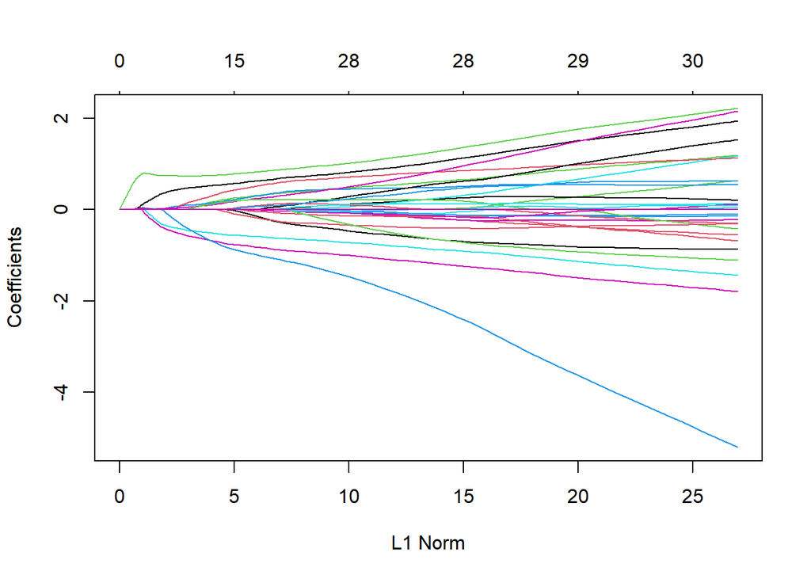

```r
plot(fit.glmnet$finalModel)
```

```r
glmnet.preds.prob=predict(fit.glmnet,test_credit,type="prob")[,"fraud"]
#We need to use lower threshold values to identify fraud
for(thr in seq(0.1,0.5,by=0.1)){
  glmnet.preds<-ifelse(glmnet.preds.prob>thr,"fraud","non_fraud")
  conf.mat<-confusionMatrix(table(glmnet.preds,test_credit$Y))
  print(thr)
  print(conf.mat)
}
```

```
## [1] 0.1
## Confusion Matrix and Statistics
##
##
## glmnet.preds fraud non_fraud
##    fraud        26        14
##    non_fraud     5      1485
##
##                Accuracy : 0.9876
##                  95% CI : (0.9807, 0.9925)
##     No Information Rate : 0.9797
##     P-Value [Acc > NIR] : 0.01367
##
##                   Kappa : 0.7261
##
##  Mcnemar's Test P-Value : 0.06646
##
##             Sensitivity : 0.83871
##             Specificity : 0.99066
##          Pos Pred Value : 0.65000
##          Neg Pred Value : 0.99664
##              Prevalence : 0.02026
##          Detection Rate : 0.01699
##    Detection Prevalence : 0.02614
##       Balanced Accuracy : 0.91469
##
##        'Positive' Class : fraud
##
## [1] 0.2
## Confusion Matrix and Statistics
##
##
## glmnet.preds fraud non_fraud
##    fraud        26         7
##    non_fraud     5      1492
##
##                Accuracy : 0.9922
##                  95% CI : (0.9863, 0.9959)
##     No Information Rate : 0.9797
##     P-Value [Acc > NIR] : 7.936e-05
```

[output cut: 85 more lines]

```
##                   Kappa : 0.8594
##
##  Mcnemar's Test P-Value : 0.2888
##
##             Sensitivity : 0.80645
##             Specificity : 0.99867
##          Pos Pred Value : 0.92593
##          Neg Pred Value : 0.99601
##              Prevalence : 0.02026
##          Detection Rate : 0.01634
##    Detection Prevalence : 0.01765
##       Balanced Accuracy : 0.90256
##
##        'Positive' Class : fraud
##
```

```r
glmnet.preds<-ifelse(glmnet.preds.prob>0.5,"fraud","non_fraud")
conf.mat<-confusionMatrix(table(glmnet.preds,test_credit$Y))
print(conf.mat)
```

```
## Confusion Matrix and Statistics
##
##
## glmnet.preds fraud non_fraud
##    fraud        25         2
##    non_fraud     6      1497
##
##                Accuracy : 0.9948
##                  95% CI : (0.9897, 0.9977)
##     No Information Rate : 0.9797
##     P-Value [Acc > NIR] : 8.105e-07
##
##                   Kappa : 0.8594
##
##  Mcnemar's Test P-Value : 0.2888
##
##             Sensitivity : 0.80645
##             Specificity : 0.99867
##          Pos Pred Value : 0.92593
##          Neg Pred Value : 0.99601
##              Prevalence : 0.02026
##          Detection Rate : 0.01634
##    Detection Prevalence : 0.01765
##       Balanced Accuracy : 0.90256
##
##        'Positive' Class : fraud
##
```

```r
glmnet.perf<-conf.mat$byClass["Balanced Accuracy"]
print(glmnet.perf)
```

```
## Balanced Accuracy
##         0.9025587
```

2. Rpart Method

```r
class.task = makeClassifTask(id = "fraud", data = train_credit, target = "Y")
resamp = makeResampleDesc("CV", iters = 10)
lrn = makeLearner("classif.rpart")
control.grid = makeTuneControlGrid()
ps = makeParamSet(
  makeDiscreteParam("cp", values = c(0.001,0.005,0.01,0.02,0.05,0.1)),
  makeDiscreteParam("minsplit", values = seq(1,11,length.out = 6))
)
set.seed(123)
fit.rpart = tuneParams(lrn, task = class.task, resampling = resamp,
                       control = control.grid, par.set = ps,
                       measures = list(ber,timetrain))# balanced error rate
```

```
## [Tune] Started tuning learner classif.rpart for parameter set:
```

```
##              Type len Def                         Constr Req Tunable Trafo
## cp       discrete   -   - 0.001,0.005,0.01,0.02,0.05,0.1   -    TRUE     -
## minsplit discrete   -   -                   1,3,5,7,9,11   -    TRUE     -
```

```
## With control class: TuneControlGrid
```

```
## Imputation value: 1Imputation value: Inf
```

```
## [Tune-x] 1: cp=0.001; minsplit=1
```

```
## [Tune-y] 1: ber.test.mean=0.1086408,timetrain.test.mean=0.0350000; time: 0.0 min
```

```
## [Tune-x] 2: cp=0.005; minsplit=1
```

```
## [Tune-y] 2: ber.test.mean=0.1086408,timetrain.test.mean=0.0340000; time: 0.0 min
```

```
## [Tune-x] 3: cp=0.01; minsplit=1
```

```
## [Tune-y] 3: ber.test.mean=0.1072135,timetrain.test.mean=0.0340000; time: 0.0 min
```

```
## [Tune-x] 4: cp=0.02; minsplit=1
```

```
## [Tune-y] 4: ber.test.mean=0.1070723,timetrain.test.mean=0.0310000; time: 0.0 min
```

```
## [Tune-x] 5: cp=0.05; minsplit=1
```

```
## [Tune-y] 5: ber.test.mean=0.1297707,timetrain.test.mean=0.0210000; time: 0.0 min
```

```
## [Tune-x] 6: cp=0.1; minsplit=1
```

```
## [Tune-y] 6: ber.test.mean=0.1349131,timetrain.test.mean=0.0250000; time: 0.0 min
```

```
## [Tune-x] 7: cp=0.001; minsplit=3
```

```
## [Tune-y] 7: ber.test.mean=0.1087841,timetrain.test.mean=0.0380000; time: 0.0 min
```

```
## [Tune-x] 8: cp=0.005; minsplit=3
```

```
## [Tune-y] 8: ber.test.mean=0.1087841,timetrain.test.mean=0.0340000; time: 0.0 min
```

```
## [Tune-x] 9: cp=0.01; minsplit=3
```

```
## [Tune-y] 9: ber.test.mean=0.1072135,timetrain.test.mean=0.0330000; time: 0.0 min
```

```
## [Tune-x] 10: cp=0.02; minsplit=3
```

```
## [Tune-y] 10: ber.test.mean=0.1070723,timetrain.test.mean=0.0330000; time: 0.0 min
```

```
## [Tune-x] 11: cp=0.05; minsplit=3
```

```
## [Tune-y] 11: ber.test.mean=0.1297707,timetrain.test.mean=0.0210000; time: 0.0 min
```

```
## [Tune-x] 12: cp=0.1; minsplit=3
```

```
## [Tune-y] 12: ber.test.mean=0.1349131,timetrain.test.mean=0.0160000; time: 0.0 min
```

```
## [Tune-x] 13: cp=0.001; minsplit=5
```

```
## [Tune-y] 13: ber.test.mean=0.1023917,timetrain.test.mean=0.0370000; time: 0.0 min
```

```
## [Tune-x] 14: cp=0.005; minsplit=5
```

```
## [Tune-y] 14: ber.test.mean=0.1023917,timetrain.test.mean=0.0360000; time: 0.0 min
```

```
## [Tune-x] 15: cp=0.01; minsplit=5
```

```
## [Tune-y] 15: ber.test.mean=0.1075004,timetrain.test.mean=0.0340000; time: 0.0 min
```

```
## [Tune-x] 16: cp=0.02; minsplit=5
```

```
## [Tune-y] 16: ber.test.mean=0.1070723,timetrain.test.mean=0.0250000; time: 0.0 min
```

```
## [Tune-x] 17: cp=0.05; minsplit=5
```

```
## [Tune-y] 17: ber.test.mean=0.1297707,timetrain.test.mean=0.0260000; time: 0.0 min
```

```
## [Tune-x] 18: cp=0.1; minsplit=5
```

```
## [Tune-y] 18: ber.test.mean=0.1349131,timetrain.test.mean=0.0210000; time: 0.0 min
```

```
## [Tune-x] 19: cp=0.001; minsplit=7
```

```
## [Tune-y] 19: ber.test.mean=0.1019639,timetrain.test.mean=0.0390000; time: 0.0 min
```

```
## [Tune-x] 20: cp=0.005; minsplit=7
```

```
## [Tune-y] 20: ber.test.mean=0.1015354,timetrain.test.mean=0.0360000; time: 0.0 min
```

```
## [Tune-x] 21: cp=0.01; minsplit=7
```

```
## [Tune-y] 21: ber.test.mean=0.1073576,timetrain.test.mean=0.0340000; time: 0.0 min
```

```
## [Tune-x] 22: cp=0.02; minsplit=7
```

```
## [Tune-y] 22: ber.test.mean=0.1070723,timetrain.test.mean=0.0340000; time: 0.0 min
```

```
## [Tune-x] 23: cp=0.05; minsplit=7
```

```
## [Tune-y] 23: ber.test.mean=0.1297707,timetrain.test.mean=0.0270000; time: 0.0 min
```

```
## [Tune-x] 24: cp=0.1; minsplit=7
```

```
## [Tune-y] 24: ber.test.mean=0.1349131,timetrain.test.mean=0.0140000; time: 0.0 min
```

```
## [Tune-x] 25: cp=0.001; minsplit=9
```

```
## [Tune-y] 25: ber.test.mean=0.1216064,timetrain.test.mean=0.0380000; time: 0.0 min
```

```
## [Tune-x] 26: cp=0.005; minsplit=9
```

```
## [Tune-y] 26: ber.test.mean=0.1210349,timetrain.test.mean=0.0330000; time: 0.0 min
```

```
## [Tune-x] 27: cp=0.01; minsplit=9
```

```
## [Tune-y] 27: ber.test.mean=0.1204651,timetrain.test.mean=0.0360000; time: 0.0 min
```

```
## [Tune-x] 28: cp=0.02; minsplit=9
```

```
## [Tune-y] 28: ber.test.mean=0.1070723,timetrain.test.mean=0.0300000; time: 0.0 min
```

```
## [Tune-x] 29: cp=0.05; minsplit=9
```

```
## [Tune-y] 29: ber.test.mean=0.1297707,timetrain.test.mean=0.0270000; time: 0.0 min
```

```
## [Tune-x] 30: cp=0.1; minsplit=9
```

```
## [Tune-y] 30: ber.test.mean=0.1349131,timetrain.test.mean=0.0230000; time: 0.0 min
```

```
## [Tune-x] 31: cp=0.001; minsplit=11
```

```
## [Tune-y] 31: ber.test.mean=0.1122159,timetrain.test.mean=0.0330000; time: 0.0 min
```

```
## [Tune-x] 32: cp=0.005; minsplit=11
```

```
## [Tune-y] 32: ber.test.mean=0.1122159,timetrain.test.mean=0.0360000; time: 0.0 min
```

```
## [Tune-x] 33: cp=0.01; minsplit=11
```

```
## [Tune-y] 33: ber.test.mean=0.1122159,timetrain.test.mean=0.0330000; time: 0.0 min
```

```
## [Tune-x] 34: cp=0.02; minsplit=11
```

```
## [Tune-y] 34: ber.test.mean=0.1122159,timetrain.test.mean=0.0320000; time: 0.0 min
```

```
## [Tune-x] 35: cp=0.05; minsplit=11
```

```
## [Tune-y] 35: ber.test.mean=0.1347707,timetrain.test.mean=0.0200000; time: 0.0 min
```

```
## [Tune-x] 36: cp=0.1; minsplit=11
```

```
## [Tune-y] 36: ber.test.mean=0.1349131,timetrain.test.mean=0.0200000; time: 0.0 min
```

```
## [Tune] Result: cp=0.005; minsplit=7 : ber.test.mean=0.1015354,timetrain.test.mean=0.0360000
```

```r
opt.grid = as.data.frame(fit.rpart$opt.path)
print(opt.grid)
```

```
##       cp minsplit ber.test.mean timetrain.test.mean dob eol error.message
## 1  0.001        1     0.1086408               0.035   1  NA          <NA>
## 2  0.005        1     0.1086408               0.034   2  NA          <NA>
## 3   0.01        1     0.1072135               0.034   3  NA          <NA>
## 4   0.02        1     0.1070723               0.031   4  NA          <NA>
## 5   0.05        1     0.1297707               0.021   5  NA          <NA>
## 6    0.1        1     0.1349131               0.025   6  NA          <NA>
## 7  0.001        3     0.1087841               0.038   7  NA          <NA>
## 8  0.005        3     0.1087841               0.034   8  NA          <NA>
## 9   0.01        3     0.1072135               0.033   9  NA          <NA>
## 10  0.02        3     0.1070723               0.033  10  NA          <NA>
## 11  0.05        3     0.1297707               0.021  11  NA          <NA>
## 12   0.1        3     0.1349131               0.016  12  NA          <NA>
## 13 0.001        5     0.1023917               0.037  13  NA          <NA>
## 14 0.005        5     0.1023917               0.036  14  NA          <NA>
```

[output cut: 59 more lines]

```r
opt.grid %>% group_by(cp) %>%
  summarise(mean(ber.test.mean),.groups="keep") %>%
  print()
```

```
## # A tibble: 6 x 2
## # Groups:   cp [6]
##   cp    `mean(ber.test.mean)`
##   <fct>                 <dbl>
## 1 0.001                 0.109
## 2 0.005                 0.109
## 3 0.01                  0.110
## 4 0.02                  0.108
## 5 0.05                  0.131
## 6 0.1                   0.135
```

```r
opt.grid %>% group_by(minsplit) %>%
  summarise(mean(ber.test.mean),.groups="keep") %>%
  print()
```

```
## # A tibble: 6 x 2
## # Groups:   minsplit [6]
##   minsplit `mean(ber.test.mean)`
##   <fct>                    <dbl>
## 1 1                        0.116
## 2 3                        0.116
## 3 5                        0.114
## 4 7                        0.114
## 5 9                        0.122
## 6 11                       0.120
```